# Spotify’s Top 100 Tracks of 2017

### An in-depth look at what we streamed the most

### Summary

This project explores the data from Spotify’s top streamed tracks of 2017. [This Kaggle dataset](https://www.kaggle.com/nadintamer/top-tracks-of-2017/data) includes Spotify’s track metadata as well as 13 different track metrics for a total of 16 data points per track: track id, track name, track artist, danceability, energy, key, loudness, mode, speechiness, acousticness, instrumentalness, liveness, valence, tempo, duration (ms), and time signature. Spotify provides a brief interpretation of these descriptors on its [developer API endpoint reference](https://developer.spotify.com/web-api/get-audio-features/).

### Artists

The top 100 tracks may be 100 individual songs, but there were only 78 unique artists total, with 16 artists having more than one track on the list. Topping the list with 4 tracks each were **Ed Sheeran** and **The Chainsmokers**.

Artists With More Than One Track

| Artist Name | Number of Tracks |
| --- | --- |
| Ed Sheeran | 4 |
| The Chainsmokers | 4 |
| Drake | 3 |
| Martin Garrix | 3 |
| Bruno Mars | 2 |
| Calvin Harris | 2 |
| Clean Bandit | 2 |
| DJ Khaled | 2 |
| Imagine Dragons | 2 |
| Kendrick Lamar | 2 |
| Khalid | 2 |
| Luis Fonsi | 2 |
| Maroon 5 | 2 |
| Post Malone | 2 |
| The Weeknd | 2 |
| ZAYN | 2 |

### Dancebility

> *Danceability describes how suitable a track is for dancing based on a combination of musical elements including tempo, rhythm stability, beat strength, and overall regularity. A value of 0.0 is least danceable and 1.0 is most danceable.*

2017’s most danceable songs were“Bad and Boujee (feat. Lil Uzi Vert)” by Migos and “Fake Love” by Drake, both with a danceability rating of **0.927**. People obviously still listened to less danceable songs, and 2017’s least danceable song was “Dusk Till Dawn - Radio Edit” by ZAYN with a danceability rating of **0.258**. As seen in the distribution and perhaps unsurprisingly, most of the tracks have a fairly high danceability rating. It seems like people like songs that they can dance to! That being said, almost a quarter of the top 100 streamed songs have a danceability rating around 7.

##### Histogram

[interactive chart not shown]

### Energy

> *Energy is a measure from 0.0 to 1.0 and represents a perceptual measure of intensity and activity. Typically, energetic tracks feel fast, loud, and noisy. For example, death metal has high energy, while a Bach prelude scores low on the scale. Perceptual features contributing to this attribute include dynamic range, perceived loudness, timbre, onset rate, and general entropy.*

The things that make a song energetic share an apparent description with house music. 2017’s most energetic song was “Just Hold On” by Steve Aoki with an energy rating of **0.932**, and 2017’s least energetic song was “Bank Account” by 21 Savage with an energy rating of **0.346**. The histogram shows two distinct groupings, both relatively quite high in energy.

##### Histogram

[interactive chart not shown]

### Key

Spotify also provides information about what key the song is in. When we look at the top streamed songs of 2017, we can see easily that the most popular key was C♯, but not by much.

##### Bar Chart

[interactive chart not shown]

### Loudness

> *The overall loudness of a track in decibels (dB). Loudness values are averaged across the entire track and are useful for comparing relative loudness of tracks. Loudness is the quality of a sound that is the primary psychological correlate of physical strength (amplitude). Values typical range between -60 and 0 db.*

There has been a war on music loudness for some time now. According to the [Wikipedia article](https://en.wikipedia.org/wiki/Loudness_war), “The loudness war (or loudness race) refers to the trend of increasing audio levels in recorded music which many critics believe reduces sound quality and listener enjoyment.” 2017’s loudest song was “Solo Dance” by Martin Jensen with an loudness rating of **-2.396**, and 2017’s quiestest song was “Location” by Khalid with an energy rating of **-11.462**. Spotify cites that the values are typically between -60 and 0, and since the quietest top streamed track was -11.462, and as shown below, most are in the -6 to -4 range, it would suggest that loud songs are popular.

##### Histogram

[interactive chart not shown]

### Mode

Spotify also provides information about whether the song is major or minor. Our most streamed songs were slightly more major, with 58 major songs and 42 minor songs.

[interactive chart not shown]

### Valence

> *A measure from 0.0 to 1.0 describing the musical positiveness conveyed by a track. Tracks with high valence sound more positive (e.g. happy, cheerful, euphoric), while tracks with low valence sound more negative (e.g. sad, depressed, angry).*

Valence is an interesting metric because it can sometimes reflect the turmoil of the times. 2017’s most positive song was “There’s Nothing Holdin’ Me Back” by Shawn Mendes with a valence rating of **0.966**, and 2017’s most negative song was “I Don’t Wanna Live Forever (Fifty Shades Darker) - From”Fifty Shades Darker (Original Motion Picture Soundtrack)“” by ZAYN with a valence rating of **0.0862**.

##### Histogram

[interactive chart not shown]

### Tempo

This [Rolling Stone Article](https://www.rollingstone.com/music/features/producers-songwriters-on-how-pop-songs-got-so-slow-w495464) details an interesting phenomenon of popular music—it’s getting slower. Between 2012 and 2017, Yakov Vorobyev found that “the average tempo dropped by 23 bpm (to 90.5 bpm) and the percentage of songs above 120 bpm fell markedly from 56 percent to 12.5 percent.” The histogram shows us that 2017 stuck with this trend, as most of the songs fall between 90 to 100 bpm.

##### Histogram

[interactive chart not shown]

### Duration

With just a short note about the length of songs, the longest song was “Bad and Boujee (feat. Lil Uzi Vert)” by Migos at 05:43 while the shortest song was “Body Like A Back Road” by Sam Hunt at 02:45.

### Correlations

Can we find any correlations between the different metrics? Including ones that weren’t discussed above, the heat map allows us to identify the strongest relationships. There’s only one relationship that’s really strong enough to mention, and that’s loudness - energy.

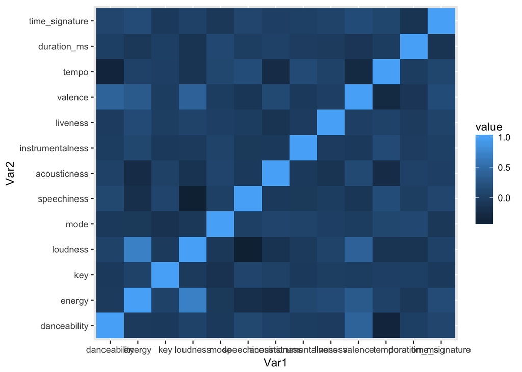